# Case Study 1 (Bike-Share)

Shesan G

25/07/2021

# Introduction

You are a junior data analyst working in the marketing analyst team at Cyclistic, a bike-share company in Chicago. The director of marketing believes the company’s future success depends on maximizing the number of annual memberships. Therefore, your team wants to understand how casual riders and annual members use Cyclistic bikes differently. From these insights, your team will design a new marketing strategy to convert casual riders into annual members. But first, Cyclistic executives must approve your recommendations, so they must be backed up with compelling data insights and professional data visualizations.

# Ask

The objective of this analysis is to discover how casual riders and annual members use the Cyclistic rental bikes different from these insights, our team can design an effective marketing strategy to convert casual riders into annual riders.

## Key Stakeholders

Lily Moreno, The director of marketing. Cyclistic marketing analytics team. Cyclistic executive team.

# Prepare

The Cyclistic historical trip data contains data sets from April 2020 to June 2021, which is available from [Cyclistic trip date] (https://divvy-tripdata.s3.amazonaws.com/index.html). The data has been made available by Motivate International Inc. under this [licence] (https://www.divvybikes.com/data-license-agreement).

The data sets are all in comma-delimited format (.CSV) with identical structures: (ride_id, rideable_type, started_at, ended_at, start_station_name, start_station_id, end_station_name, end_station_id, start_lat, start_lng, end_lat, end_lng, member_casual).

# Process

```r
library(tidyverse)
library(lubridate)
library(ggplot2)
library(ggmap)
#library(RColorBrewer)
library(scales)

#scipen prints values in numeric values instead of fixed or exponential notation (helpful for graph scales).
options(scipen = 5)
```

Merge the files together into a single dataset.

```r
bike_files <- list.files(path = "./Data/", recursive = TRUE, full.name = TRUE, pattern = "*-divvy-tripdata.csv")
bike_merged <- do.call(rbind, lapply(bike_files, read.csv))
print((paste(nrow(bike_merged), "Rows Total")))
```

```
## [1] "5088206 Rows Total"
```

Structure of the data.

```r
str(bike_merged)
```

```
## 'data.frame':    5088206 obs. of  13 variables:
##  $ ride_id           : chr  "A847FADBBC638E45" "5405B80E996FF60D" "5DD24A79A4E006F4" "2A59BBDF5CDBA725" ...
##  $ rideable_type     : chr  "docked_bike" "docked_bike" "docked_bike" "docked_bike" ...
##  $ started_at        : chr  "2020-04-26 17:45" "2020-04-17 17:08" "2020-04-01 17:54" "2020-04-07 12:50" ...
##  $ ended_at          : chr  "2020-04-26 18:12" "2020-04-17 17:17" "2020-04-01 18:08" "2020-04-07 13:02" ...
##  $ start_station_name: chr  "Eckhart Park" "Drake Ave & Fullerton Ave" "McClurg Ct & Erie St" "California Ave & Division St" ...
##  $ start_station_id  : chr  "86" "503" "142" "216" ...
##  $ end_station_name  : chr  "Lincoln Ave & Diversey Pkwy" "Kosciuszko Park" "Indiana Ave & Roosevelt Rd" "Wood St & Augusta Blvd" ...
##  $ end_station_id    : chr  "152" "499" "255" "657" ...
##  $ start_lat         : num  41.9 41.9 41.9 41.9 41.9 ...
##  $ start_lng         : num  -87.7 -87.7 -87.6 -87.7 -87.6 ...
##  $ end_lat           : num  41.9 41.9 41.9 41.9 42 ...
##  $ end_lng           : num  -87.7 -87.7 -87.6 -87.7 -87.7 ...
##  $ member_casual     : chr  "member" "member" "member" "member" ...
```

Removed duplicate rider id’s.

```r
bike_unique <- bike_merged[!duplicated(bike_merged$ride_id), ]
print(paste(nrow(bike_merged) - nrow(bike_unique), "Duplicates Rows Removed "))
```

```
## [1] "209 Duplicates Rows Removed "
```

Removed rows where values were missing. These rows include start_station_id, end_station_id, end_lat, and end_lng.

```r
colSums(is.na(bike_unique))
```

```
##            ride_id      rideable_type         started_at           ended_at
##                  0                  0                  0                  0
## start_station_name   start_station_id   end_station_name     end_station_id
##                  0              83583                  0              98104
##          start_lat          start_lng            end_lat            end_lng
##                  0                  0               6173               6173
##      member_casual
##                  0
```

```r
bike_prepared <- bike_unique %>%
  drop_na() %>%
  filter(start_station_name != "" | end_station_name != "")
print((paste(nrow(bike_unique) - nrow(bike_prepared), "Missing/Null Rows Removed")))
```

```
## [1] "253237 Missing/Null Rows Removed"
```

```r
colSums(is.na(bike_prepared))
```

```
##            ride_id      rideable_type         started_at           ended_at
##                  0                  0                  0                  0
## start_station_name   start_station_id   end_station_name     end_station_id
##                  0                  0                  0                  0
##          start_lat          start_lng            end_lat            end_lng
##                  0                  0                  0                  0
##      member_casual
##                  0
```

Format the structure of the dates.

```r
bike_prepared$started_at <- as.POSIXct(bike_prepared$started_at, format = "%Y-%m-%d %H:%M")
bike_prepared$ended_at <- as.POSIXct(bike_prepared$ended_at, format = "%Y-%m-%d %H:%M")
```

Mutate columns to allow detailed analysis.

```r
bike_prepared <- bike_prepared %>%
  mutate(ride_length_sec = as.numeric(difftime(bike_prepared$ended_at,bike_prepared$started_at))) %>%
  mutate(ride_length_min = as.numeric(difftime(bike_prepared$ended_at,bike_prepared$started_at, units = "mins"))) %>%
  mutate(day_of_week_char = weekdays(bike_prepared$started_at)) %>%
  mutate(day_of_week_num = wday((bike_prepared$started_at))) %>%
  mutate(start_hour = hour(bike_prepared$started_at)) %>%
  mutate(start_day = day(bike_prepared$started_at)) %>%
  mutate(start_month = month(bike_prepared$started_at)) %>%
  mutate(start_year = year(bike_prepared$started_at)) %>%
  mutate(start_year_month = paste(start_year, start_month, sep = "-"))
```

Order the data

```r
bike_prepared$day_of_week_char <- ordered(bike_prepared$day_of_week_char, levels=c("Sunday", "Monday", "Tuesday", "Wednesday", "Thursday", "Friday", "Saturday"))

bike_prepared$start_year_month <- ordered(bike_prepared$start_year_month, levels=c("2020-4", "2020-5", "2020-6", "2020-7", "2020-8", "2020-9", "2020-10", "2020-11", "2020-12", "2021-1",  "2021-2", "2021-3",  "2021-4",  "2021-5",  "2021-6"))
```

Remove ride lengths with negative values.

```r
bike_prepared_2 <- bike_prepared %>%
  filter(ride_length_sec > 0)
print((paste(nrow(bike_prepared) - nrow(bike_prepared_2), "Rows Removed, ride length invalid")))
```

```
## [1] "49382 Rows Removed, ride length invalid"
```

Save the file/Load the file (if required).

```r
#bike_prepared_2 %>% write.csv("./Data/Cleaned_Bike_200204_202106.csv")
#bike_prepared_2 <- read.csv("./Data/Cleaned_Bike_200204_202106.csv")
```

# Analyse

Summary data of the ride length in minutes.

```r
summary(bike_prepared_2$ride_length_min)
```

```
##     Min.  1st Qu.   Median     Mean  3rd Qu.     Max.
##     1.00     8.00    14.00    27.37    26.00 58720.00
```

```r
setNames(aggregate(bike_prepared_2$ride_length_min ~ bike_prepared_2$member_casual, FUN = mean),
         c("member/casual", "ride_len_minute_mean"))
```

```
##   member/casual ride_len_minute_mean
## 1        casual             42.81765
## 2        member             15.67913
```

```r
setNames(aggregate(bike_prepared_2$ride_length_min ~ bike_prepared_2$member_casual, FUN = median),
         c("member/casual", "ride_len_minute_median"))
```

```
##   member/casual ride_len_minute_median
## 1        casual                     21
## 2        member                     11
```

```r
setNames(aggregate(bike_prepared_2$ride_length_min ~ bike_prepared_2$member_casual, FUN = max),
         c("member/casual", "ride_len_minute_max"))
```

```
##   member/casual ride_len_minute_max
## 1        casual               55944
## 2        member               58720
```

```r
setNames(aggregate(bike_prepared_2$ride_length_min ~ bike_prepared_2$member_casual, FUN = min),
         c("member/casual", "ride_len_minute_min"))
```

```
##   member/casual ride_len_minute_min
## 1        casual                   1
## 2        member                   1
```

```r
setNames(aggregate(bike_prepared_2$ride_length_min ~ bike_prepared_2$member_casual + bike_prepared_2$day_of_week_char, FUN = mean),
         c("member/casual", "day_of_week", "ride_len_minute_mean"))
```

```
##    member/casual day_of_week ride_len_minute_mean
## 1         casual      Sunday             48.45764
## 2         member      Sunday             17.85978
## 3         casual      Monday             41.63353
## 4         member      Monday             14.92607
## 5         casual     Tuesday             38.48802
## 6         member     Tuesday             14.74887
## 7         casual   Wednesday             38.66060
## 8         member   Wednesday             14.77410
## 9         casual    Thursday             40.18832
## 10        member    Thursday             14.76470
## 11        casual      Friday             41.24203
## 12        member      Friday             15.31332
## 13        casual    Saturday             44.81991
## 14        member    Saturday             17.43437
```

```r
#bike_prepared_2 %>% group_by(member_casual, day_of_week_char) %>% summarise_at(vars(ride_length_min), funs(mean, median, max, min))
```

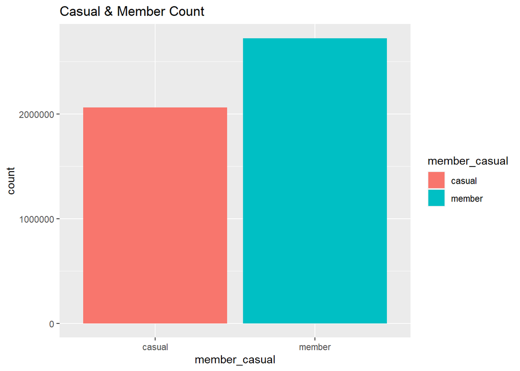

```r
bike_prepared_2 %>%
  ggplot(aes(x = member_casual, fill = member_casual)) +
  geom_bar() +
  labs(title = "Casual & Member Count")
```

```r
table(bike_prepared_2$member_casual)
```

```
##
##  casual  member
## 2061224 2724154
```

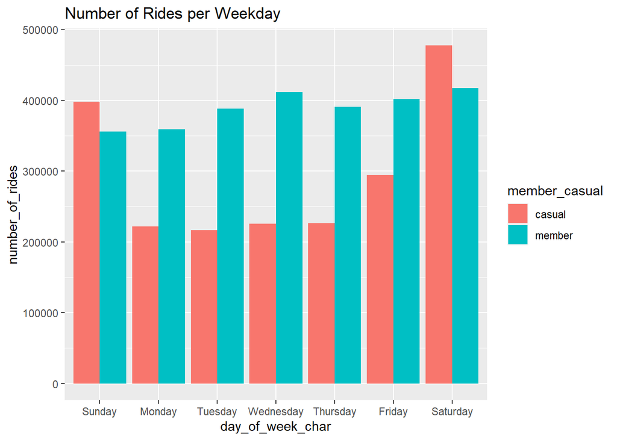

```r
bike_prepared_2 %>%
  group_by(member_casual, day_of_week_char) %>%
  summarise(number_of_rides = n(), average_duration = mean(ride_length_min)) %>%
  arrange(member_casual, day_of_week_char) %>%
  ggplot(aes(x = day_of_week_char, y = number_of_rides, fill = member_casual)) +
  geom_col(position = "dodge") +
  labs(title = "Number of Rides per Weekday")
```

```r
#Number of rides on weekday (Monday - Friday)
bike_prepared_2 %>%
  group_by(member_casual, day_of_week_char) %>%
  summarise(number_of_rides = n(), average_duration = mean(ride_length_min)) %>%
  subset(., day_of_week_char != "Saturday" & day_of_week_char != "Sunday") %>%
  summarise(sum(number_of_rides))
```

```
## # A tibble: 2 x 2
##   member_casual `sum(number_of_rides)`
##   <chr>                          <int>
## 1 casual                       1185574
## 2 member                       1951110
```

```r
#Number of rides on weekend (Saturday, Sunday)
bike_prepared_2 %>%
  group_by(member_casual, day_of_week_char) %>%
  summarise(number_of_rides = n(), average_duration = mean(ride_length_min)) %>%
  subset(., day_of_week_char != "Monday" & day_of_week_char != "Tuesday" & day_of_week_char != "Wednesday" & day_of_week_char != "Thursday" & day_of_week_char != "Friday") %>%
  summarise(sum(number_of_rides))
```

```
## # A tibble: 2 x 2
##   member_casual `sum(number_of_rides)`
##   <chr>                          <int>
## 1 casual                        875650
## 2 member                        773044
```

[figure not shown]

```r
bike_prepared_2 %>%
  group_by(member_casual, day_of_week_char) %>%
  summarise(number_of_rides = n(), average_duration = mean(ride_length_min)) %>%
  arrange(member_casual, day_of_week_char) %>%
  ggplot(aes(x = day_of_week_char, y = average_duration, fill = member_casual)) +
  geom_col(position = "dodge") +
  labs(title = "Average Number of Rides per Weekday")
```

```r
bike_prepared_2 %>%
  group_by(member_casual) %>%
  summarise(number_of_rides = n(), average_duration = mean(ride_length_min))
```

```
## # A tibble: 2 x 3
##   member_casual number_of_rides average_duration
##   <chr>                   <int>            <dbl>
## 1 casual                2061224             42.8
## 2 member                2724154             15.7
```

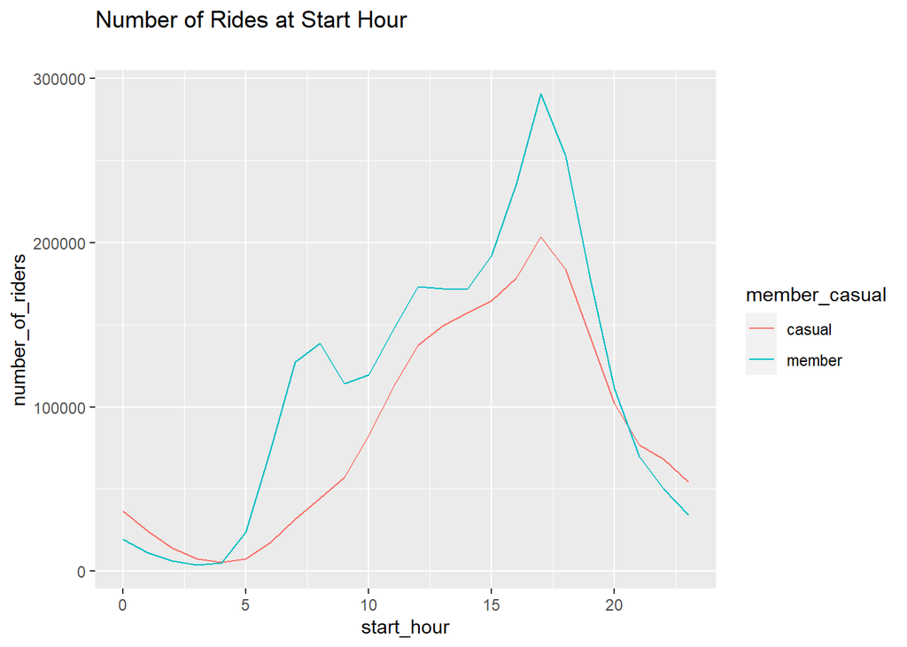

```r
bike_prepared_2 %>%
  group_by(member_casual, start_hour) %>%
  summarise(number_of_riders = n()) %>%
  ggplot(aes(x = start_hour, y = number_of_riders, color = member_casual)) +
  geom_line() +
  labs(title = "Number of Rides at Start Hour", subtitle = "")
```

```r
bike_prepared_2 %>%
  group_by(start_hour) %>%
  summarise(number_of_riders = n()) %>%
  arrange(number_of_riders)
```

```
## # A tibble: 24 x 2
##    start_hour number_of_riders
##         <int>            <int>
##  1          4            10563
##  2          3            10943
##  3          2            20167
##  4          5            31624
##  5          1            35688
##  6          0            56073
##  7         23            88261
##  8          6            92269
##  9         22           118440
## 10         21           146675
## # ... with 14 more rows
```

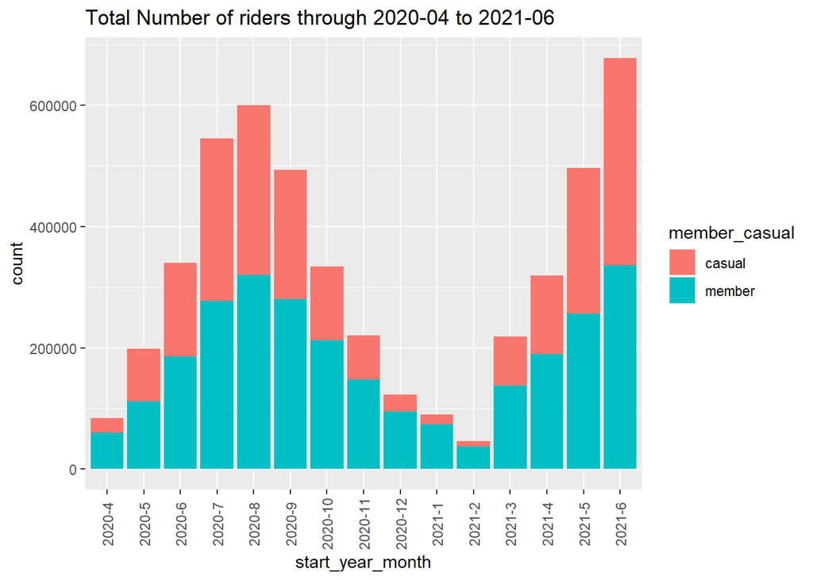

```r
bike_prepared_2 %>%
  ggplot(aes(x = start_year_month, fill = member_casual)) +
  geom_bar() +
  labs(title = "Total Number of riders through 2020-04 to 2021-06") +
  theme(axis.text.x = element_text(angle = 90, vjust = 0.5))
```

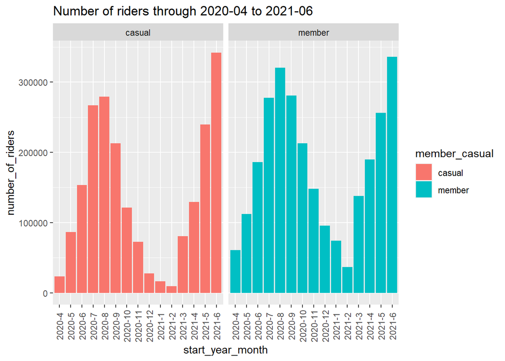

```r
bike_prepared_2 %>%
  group_by(member_casual, start_year_month) %>%
  summarize(number_of_riders = n()) %>%
  ggplot(aes(x = start_year_month, y = number_of_riders, fill = member_casual)) +
  geom_col(position = "dodge") +
  facet_wrap(~ member_casual) +
  labs(title = "Number of riders through 2020-04 to 2021-06") +
  theme(axis.text.x = element_text(angle = 90, vjust = 0.5))
```

```r
bike_prepared_2 %>%
  group_by(start_year_month) %>%
  summarize(number_of_riders = n()) %>%
  arrange(number_of_riders)
```

```
## # A tibble: 15 x 2
##    start_year_month number_of_riders
##    <ord>                       <int>
##  1 2021-2                      46124
##  2 2020-4                      84035
##  3 2021-1                      90519
##  4 2020-12                    122975
##  5 2020-5                     198396
##  6 2021-3                     218121
##  7 2020-11                    220223
##  8 2021-4                     319430
##  9 2020-10                    334033
## 10 2020-6                     339629
## 11 2020-9                     493676
## 12 2021-5                     495945
## 13 2020-7                     544747
## 14 2020-8                     599616
## 15 2021-6                     677909
```

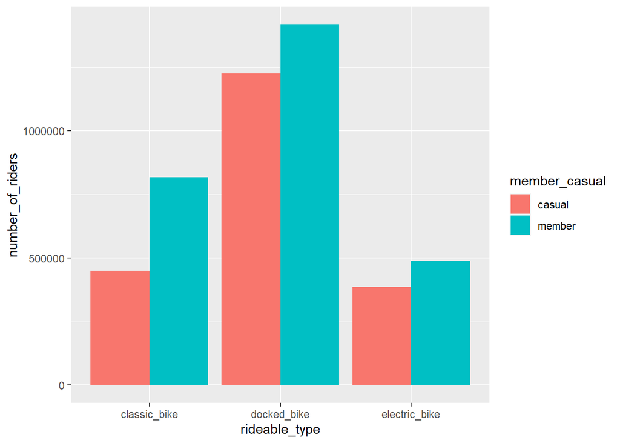

```r
bike_prepared_2 %>%
  group_by(member_casual, rideable_type, ) %>%
  summarize(number_of_riders = n()) %>%
  ggplot(aes(x = rideable_type, y = number_of_riders, fill = member_casual)) +
  geom_col(position = "dodge")
```